# R Notebook

# Load data

I am using the AHA dataset for writing my code because it is the simplest dataset I can work with. Simplest = significant number of baseline samples without issue of repeated measures, balanced distribution of classes, likely difference to be detected present.

```r
a_ps = readRDS("/Users/aa370/Library/CloudStorage/Box-Box/project_davidlab/LAD_LAB_Personnel/Ammara_A/Projects/AHA/220714_MN00462_0226_A000H3WKM5/20221110_results/ps_objects/AHA_trnl_with_metadata_20221205.rds")

a_ps
```

```
phyloseq-class experiment-level object
otu_table()   OTU Table:         [ 235 taxa and 95 samples ]
sample_data() Sample Data:       [ 95 samples by 33 sample variables ]
tax_table()   Taxonomy Table:    [ 235 taxa by 10 taxonomic ranks ]
```

# Preprocess

## Remove problematic samples

Taking out samples that are not listed to have completed the study and samples with more than 0 reads reduces samples from 95 down to 77.

Taking only the baseline timepoint brings further down to 44 samples

```r
a_ps = a_ps %>%
  subset_samples(completion == "Completed" & reads >0) %>%
  subset_samples(timepoint == "Baseline")

a_ps
```

```
phyloseq-class experiment-level object
otu_table()   OTU Table:         [ 235 taxa and 44 samples ]
sample_data() Sample Data:       [ 44 samples by 33 sample variables ]
tax_table()   Taxonomy Table:    [ 235 taxa by 10 taxonomic ranks ]
```

Class distribution in this dataset: Case = 20 Control = 24

```r
sample_data(a_ps) %>%
  as.data.frame() %>%
  as_tibble() %>%
  group_by(group) %>%
  summarise(count = n())
```

| group | count |
| --- | --- |
| Case | 20 |
| Control | 24 |

## Remove unassigned taxa

Debating whether this should be done for machine learning. Because we are simply throwing out because we don’t know what there are and even if they account for a small percentage of reads, they might still have important information.

I think I will refrain from removing unless I have a good reason to.

Don’t do this because some very important taxa for ML model turned out to be unassigned. - 12/8/22

Removing completely unassigned taxa reduces taxa from 235 to 82.

```r
a_ps = a_ps %>%
  subset_taxa(is.na(superkingdom) == FALSE)

a_ps
```

```
phyloseq-class experiment-level object
otu_table()   OTU Table:         [ 82 taxa and 44 samples ]
sample_data() Sample Data:       [ 44 samples by 33 sample variables ]
tax_table()   Taxonomy Table:    [ 82 taxa by 10 taxonomic ranks ]
```

## Data transform

```r
otu_clr = abundances(a_ps, "clr") %>% # rclr transform could not be performed, get Nans
  t()

a_ps = phyloseq(otu_table(otu_clr, taxa_are_rows = FALSE),
                   sample_data(sample_data(a_ps)),
                   tax_table(tax_table(a_ps)))

rm(otu_clr)
```

## Feature table

### Extract data

Order of asv colnames in OTU table and tax table is the same.

```r
features = a_ps@otu_table %>%
  as.data.frame() %>%
  as_tibble(rownames = NA) %>%
  rownames_to_column("sample")

feature_labels = c("sample")

 names = tax_table(a_ps) %>%
      data.frame() %>%
      lowest_level() %>%
   pull(name)

 feature_labels = append(feature_labels, names)

 feature_labels = make.unique(feature_labels) %>%
   make.names()

 colnames(features) = feature_labels

features
```

| sample | Poaceae | Rosaceae | Zea.mays | Vitis | Avena.sativa | Apiaceae | Solanaceae | Musa | Rosaceae.1 | Ilex.paraguariensis | Theobroma.cacao | Fabaceae | Lauraceae | Mangifera.indica | Capsicum | Brassicaceae | Vaccinium | Brassica.oleracea | Lamiales | Spinacia | Coriandrum.sativum | Piper | Oryza.sativa | Lactuca.sativa | Solanum.lycopersicum | Phaseolus | Sorghum.bicolor | Allium | Pyrus.communis | … |
| --- | --- | --- | --- | --- | --- | --- | --- | --- | --- | --- | --- | --- | --- | --- | --- | --- | --- | --- | --- | --- | --- | --- | --- | --- | --- | --- | --- | --- | --- | --- |
| AHA1-2-A01 | 6.4014324 | 8.6002711 | 8.7894181 | -0.5326567 | 4.4329046 | 7.8652994 | 5.4836633 | -0.5326567 | -0.5326567 | -0.5326567 | 5.7640884 | -0.5326567 | -0.5326567 | -0.5326567 | 6.1637354 | -0.5326567 | 4.2072938 | -0.5326567 | 3.7127070 | -0.5326567 | -0.5326567 | 4.6168677 | 5.0925559 | -0.5326567 | 3.8114247 | -0.5326567 | -0.5326567 | -0.5326567 | -0.5326567 | … |
| AHA1-2-A02 | 7.3994768 | 8.6579915 | 8.9966693 | 4.4201570 | 4.3209173 | 3.8935595 | 8.5411603 | 2.2851132 | -0.4057425 | 3.5834948 | 4.5932264 | -0.4057425 | 3.6870022 | -0.4057425 | 3.1317029 | -0.4057425 | -0.4057425 | -0.4057425 | -0.4057425 | -0.4057425 | -0.4057425 | -0.4057425 | -0.4057425 | -0.4057425 | -0.4057425 | 4.6321877 | -0.4057425 | 2.8723491 | -0.4057425 | … |
| AHA1-2-A06 | 6.7695110 | 3.9570164 | 8.4837201 | -0.5409814 | -0.5409814 | 4.3472899 | 7.7954760 | 3.6384745 | 2.8113803 | -0.5409814 | 6.9908810 | 5.6494820 | -0.5409814 | -0.5409814 | 3.4307605 | -0.5409814 | -0.5409814 | -0.5409814 | 6.5455103 | -0.5409814 | 3.5400010 | 3.3081063 | -0.5409814 | 7.8483709 | 5.6431858 | -0.5409814 | -0.5409814 | -0.5409814 | -0.5409814 | … |
| AHA1-2-A08 | 5.9363843 | -0.4513964 | 8.8443895 | 8.2547706 | -0.4513964 | 8.4292396 | 3.6126308 | 2.5770614 | 8.2034549 | -0.4513964 | 2.4865786 | 4.4934205 | -0.4513964 | -0.4513964 | 3.8323325 | 3.3705695 | -0.4513964 | -0.4513964 | 2.9365175 | -0.4513964 | -0.4513964 | 4.1996069 | -0.4513964 | 3.6722444 | -0.4513964 | -0.4513964 | -0.4513964 | -0.4513964 | -0.4513964 | … |
| AHA1-2-A10 | 8.4496740 | 3.1350805 | 5.2487536 | -0.5261808 | -0.5261808 | 4.4647041 | 9.1864099 | -0.5261808 | 2.7974253 | -0.5261808 | 7.2910483 | -0.5261808 | -0.5261808 | -0.5261808 | -0.5261808 | 4.4260585 | -0.5261808 | -0.5261808 | 5.8905945 | -0.5261808 | -0.5261808 | 6.8203880 | 6.7747884 | -0.5261808 | -0.5261808 | -0.5261808 | -0.5261808 | 3.9634204 | -0.5261808 | … |
| AHA1-2-A12 | 6.7274281 | -0.4407491 | 7.8972180 | -0.4407491 | -0.4407491 | 8.3778945 | -0.4407491 | 4.0104339 | -0.4407491 | 2.1321717 | 8.1671468 | 5.5141541 | -0.4407491 | -0.4407491 | -0.4407491 | -0.4407491 | -0.4407491 | 4.9165364 | -0.4407491 | 8.9658365 | -0.4407491 | 5.2925295 | 4.6069428 | 6.2570576 | -0.4407491 | -0.4407491 | -0.4407491 | 2.4761357 | -0.4407491 | … |
| AHA1-2-B01 | 5.4336106 | 7.3581827 | 6.8083559 | 2.7605480 | 1.9124514 | 9.9319249 | -0.2960239 | 3.6283959 | 4.8041430 | -0.2960239 | -0.2960239 | -0.2960239 | -0.2960239 | -0.2960239 | -0.2960239 | 2.2004830 | 5.9251890 | -0.2960239 | -0.2960239 | -0.2960239 | -0.2960239 | 1.0997715 | 1.9124514 | -0.2960239 | -0.2960239 | -0.2960239 | -0.2960239 | -0.2960239 | -0.2960239 | … |
| AHA1-2-B03 | 8.2226276 | -0.7530304 | 7.8046274 | -0.7530304 | -0.7530304 | 6.1574218 | 3.7526686 | 6.4393229 | 8.3404706 | -0.7530304 | 4.8040357 | 5.3051385 | -0.7530304 | -0.7530304 | 5.1423077 | -0.7530304 | -0.7530304 | -0.7530304 | 3.9331474 | -0.7530304 | -0.7530304 | 5.0639424 | 3.6420579 | 6.9590004 | 3.3053225 | -0.7530304 | 5.6195872 | -0.7530304 | -0.7530304 | … |
| AHA1-2-B06 | 7.4967000 | 5.9838289 | 7.4866533 | 8.5402743 | -0.4477073 | 7.2860622 | -0.4477073 | 4.9750415 | 8.1278058 | -0.4477073 | 4.2862995 | -0.4477073 | -0.4477073 | -0.4477073 | -0.4477073 | 6.2596936 | -0.4477073 | 7.0348728 | 5.5327633 | -0.4477073 | -0.4477073 | -0.4477073 | -0.4477073 | 5.1973016 | -0.4477073 | 7.9476469 | -0.4477073 | -0.4477073 | -0.4477073 | … |
| AHA1-2-B07 | 8.0484667 | 8.9700750 | 7.5680468 | -0.4861739 | 6.4143609 | -0.4861739 | -0.4861739 | 6.4035610 | -0.4861739 | 4.1926719 | 5.9077784 | -0.4861739 | -0.4861739 | 5.2163015 | -0.4861739 | -0.4861739 | -0.4861739 | -0.4861739 | -0.4861739 | -0.4861739 | -0.4861739 | 3.2902196 | -0.4861739 | 6.5637527 | 6.8230656 | -0.4861739 | -0.4861739 | -0.4861739 | -0.4861739 | … |

[output cut: 34 more lines]

### Zero variance features

No features have zero variance

```r
nzv = features %>%
  select(!sample) %>%
  nearZeroVar(saveMetrics = TRUE)
```

```r
rm(nzv)
```

### Correlated predictors

```r
feature_cor = features %>%
 select(!sample) %>%
 cor()

summary(feature_cor[upper.tri(feature_cor)])
```

```
    Min.  1st Qu.   Median     Mean  3rd Qu.     Max.
-0.71179 -0.10232  0.04377  0.15110  0.28688  1.00000
```

```r
high_cor = findCorrelation(feature_cor, cutoff = .75)

filtered_features = features[,-high_cor]
```

```r
rm(high_cor)
rm(feature_cor)
```

### Linear dependencies

```r
feature_ld = filtered_features %>%
  select(!sample) %>%
  findLinearCombos()

filtered_features = filtered_features[, - feature_ld$remove]
```

## Input table

| sample | group | group_shuffle | Poaceae | Rosaceae | Zea.mays | Vitis | Avena.sativa | Apiaceae | Solanaceae | Musa | Rosaceae.1 | Ilex.paraguariensis | Theobroma.cacao | Fabaceae | Lauraceae | Mangifera.indica | Capsicum | Brassicaceae | Vaccinium | Brassica.oleracea | Lamiales | Spinacia | Coriandrum.sativum | Piper | Oryza.sativa | Lactuca.sativa | Solanum.lycopersicum | Phaseolus | Sorghum.bicolor | … |
| --- | --- | --- | --- | --- | --- | --- | --- | --- | --- | --- | --- | --- | --- | --- | --- | --- | --- | --- | --- | --- | --- | --- | --- | --- | --- | --- | --- | --- | --- | --- |
| AHA1-2-A01 | Control | Case | 6.4014324 | 8.6002711 | 8.7894181 | -0.5326567 | 4.4329046 | 7.8652994 | 5.4836633 | -0.5326567 | -0.5326567 | -0.5326567 | 5.7640884 | -0.5326567 | -0.5326567 | -0.5326567 | 6.1637354 | -0.5326567 | 4.2072938 | -0.5326567 | 3.7127070 | -0.5326567 | -0.5326567 | 4.6168677 | 5.0925559 | -0.5326567 | 3.8114247 | -0.5326567 | -0.5326567 | … |
| AHA1-2-A02 | Case | Case | 7.3994768 | 8.6579915 | 8.9966693 | 4.4201570 | 4.3209173 | 3.8935595 | 8.5411603 | 2.2851132 | -0.4057425 | 3.5834948 | 4.5932264 | -0.4057425 | 3.6870022 | -0.4057425 | 3.1317029 | -0.4057425 | -0.4057425 | -0.4057425 | -0.4057425 | -0.4057425 | -0.4057425 | -0.4057425 | -0.4057425 | -0.4057425 | -0.4057425 | 4.6321877 | -0.4057425 | … |
| AHA1-2-A06 | Case | Case | 6.7695110 | 3.9570164 | 8.4837201 | -0.5409814 | -0.5409814 | 4.3472899 | 7.7954760 | 3.6384745 | 2.8113803 | -0.5409814 | 6.9908810 | 5.6494820 | -0.5409814 | -0.5409814 | 3.4307605 | -0.5409814 | -0.5409814 | -0.5409814 | 6.5455103 | -0.5409814 | 3.5400010 | 3.3081063 | -0.5409814 | 7.8483709 | 5.6431858 | -0.5409814 | -0.5409814 | … |
| AHA1-2-A08 | Control | Case | 5.9363843 | -0.4513964 | 8.8443895 | 8.2547706 | -0.4513964 | 8.4292396 | 3.6126308 | 2.5770614 | 8.2034549 | -0.4513964 | 2.4865786 | 4.4934205 | -0.4513964 | -0.4513964 | 3.8323325 | 3.3705695 | -0.4513964 | -0.4513964 | 2.9365175 | -0.4513964 | -0.4513964 | 4.1996069 | -0.4513964 | 3.6722444 | -0.4513964 | -0.4513964 | -0.4513964 | … |
| AHA1-2-A10 | Control | Case | 8.4496740 | 3.1350805 | 5.2487536 | -0.5261808 | -0.5261808 | 4.4647041 | 9.1864099 | -0.5261808 | 2.7974253 | -0.5261808 | 7.2910483 | -0.5261808 | -0.5261808 | -0.5261808 | -0.5261808 | 4.4260585 | -0.5261808 | -0.5261808 | 5.8905945 | -0.5261808 | -0.5261808 | 6.8203880 | 6.7747884 | -0.5261808 | -0.5261808 | -0.5261808 | -0.5261808 | … |
| AHA1-2-A12 | Control | Control | 6.7274281 | -0.4407491 | 7.8972180 | -0.4407491 | -0.4407491 | 8.3778945 | -0.4407491 | 4.0104339 | -0.4407491 | 2.1321717 | 8.1671468 | 5.5141541 | -0.4407491 | -0.4407491 | -0.4407491 | -0.4407491 | -0.4407491 | 4.9165364 | -0.4407491 | 8.9658365 | -0.4407491 | 5.2925295 | 4.6069428 | 6.2570576 | -0.4407491 | -0.4407491 | -0.4407491 | … |
| AHA1-2-B01 | Case | Case | 5.4336106 | 7.3581827 | 6.8083559 | 2.7605480 | 1.9124514 | 9.9319249 | -0.2960239 | 3.6283959 | 4.8041430 | -0.2960239 | -0.2960239 | -0.2960239 | -0.2960239 | -0.2960239 | -0.2960239 | 2.2004830 | 5.9251890 | -0.2960239 | -0.2960239 | -0.2960239 | -0.2960239 | 1.0997715 | 1.9124514 | -0.2960239 | -0.2960239 | -0.2960239 | -0.2960239 | … |
| AHA1-2-B03 | Control | Case | 8.2226276 | -0.7530304 | 7.8046274 | -0.7530304 | -0.7530304 | 6.1574218 | 3.7526686 | 6.4393229 | 8.3404706 | -0.7530304 | 4.8040357 | 5.3051385 | -0.7530304 | -0.7530304 | 5.1423077 | -0.7530304 | -0.7530304 | -0.7530304 | 3.9331474 | -0.7530304 | -0.7530304 | 5.0639424 | 3.6420579 | 6.9590004 | 3.3053225 | -0.7530304 | 5.6195872 | … |
| AHA1-2-B06 | Control | Control | 7.4967000 | 5.9838289 | 7.4866533 | 8.5402743 | -0.4477073 | 7.2860622 | -0.4477073 | 4.9750415 | 8.1278058 | -0.4477073 | 4.2862995 | -0.4477073 | -0.4477073 | -0.4477073 | -0.4477073 | 6.2596936 | -0.4477073 | 7.0348728 | 5.5327633 | -0.4477073 | -0.4477073 | -0.4477073 | -0.4477073 | 5.1973016 | -0.4477073 | 7.9476469 | -0.4477073 | … |
| AHA1-2-B07 | Control | Control | 8.0484667 | 8.9700750 | 7.5680468 | -0.4861739 | 6.4143609 | -0.4861739 | -0.4861739 | 6.4035610 | -0.4861739 | 4.1926719 | 5.9077784 | -0.4861739 | -0.4861739 | 5.2163015 | -0.4861739 | -0.4861739 | -0.4861739 | -0.4861739 | -0.4861739 | -0.4861739 | -0.4861739 | 3.2902196 | -0.4861739 | 6.5637527 | 6.8230656 | -0.4861739 | -0.4861739 | … |

[output cut: 34 more lines]

# Modeling

Load functions from classification_function_AA file

```r
label_list = c("group", "group_shuffle")
results = loop_label(iterations = 20, input, label_list, percent = 0.7)
```

```
[1] "group"
[[1]]
[1] "group"

[[2]]
          Reference
Prediction Case Control
   Case      68      34
   Control   52     106
```

```
[1] "group_shuffle"
[[1]]
[1] "group_shuffle"

[[2]]
          Reference
Prediction Case Control
   Case      51      55
   Control   69      85
```

```r
auc_df = results[[2]]

importance_df = results[[1]]
```

```r
rm(label_list)
```

# Plotting

## AUC plot and t-test

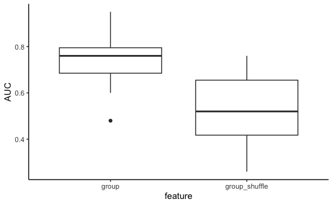

```r
auc_df %>%
  pivot_longer(cols = c("group", "group_shuffle"), names_to = "feature", values_to = "AUC") %>%
  ggplot()+
  geom_boxplot(aes(x=feature, y = AUC))+
  theme_classic()
```

```r
t.test(auc_df$group, auc_df$group_shuffle)
```

```
    Welch Two Sample t-test

data:  auc_df$group and auc_df$group_shuffle
t = 4.7201, df = 35.917, p-value = 3.539e-05
alternative hypothesis: true difference in means is not equal to 0
95 percent confidence interval:
 0.1154841 0.2895159
sample estimates:
mean of x mean of y
   0.7405    0.5380
```

## Importance plots

### look-up table

```r
#Making asv reference for names in model
lookup_asv = tax_table(a_ps) %>%
     data.frame() %>%
      lowest_level() %>%
   rownames_to_column("asv") %>%
   select(asv, name) %>%
   mutate(name = make.names(make.unique(name)))
```

### summarize importances

```r
# Making summary df of importances
importance_summary = importance_df %>%
  pivot_longer(cols = c("NA.1":"Solanum.lycopersicum"), names_to = "food", values_to = "importance") %>%
  group_by(variable, food) %>%
  summarise(mean_importance = mean(importance)) %>%
  arrange(variable, desc(mean_importance))
```

### top 10 ranked list

```r
# Getting the ranked list
ranking = importance_summary %>%
  filter(variable == "group_shuffle") %>%
  pull(food)

top10 = ranking[1:10]
```

### Importance plot

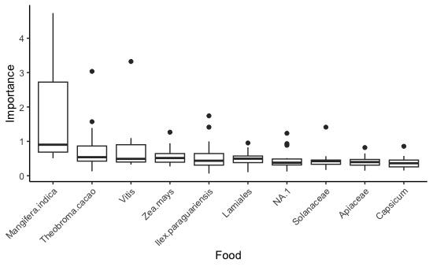

```r
importance_df %>%
  pivot_longer(cols = c("NA.1":"Solanum.lycopersicum"), names_to = "food", values_to = "importance")  %>%
  filter(variable == "group_shuffle" & food %in% top10) %>%
  ggplot()+
  geom_boxplot(aes(x= reorder(food,-importance), y = importance))+
  labs(x= "Food", y ="Importance") +
  theme_classic() +
  theme(axis.text.x = element_text(angle = 45, hjust=1))
```

Some of the important NAs for predictions only map to bacterial species in BLAST.

# Important taxa directions

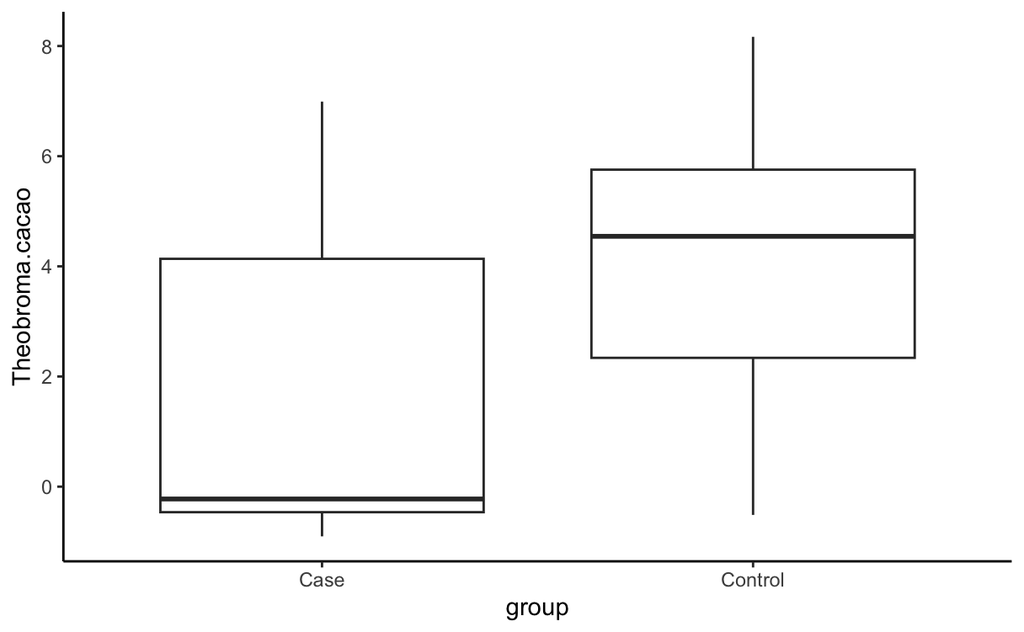

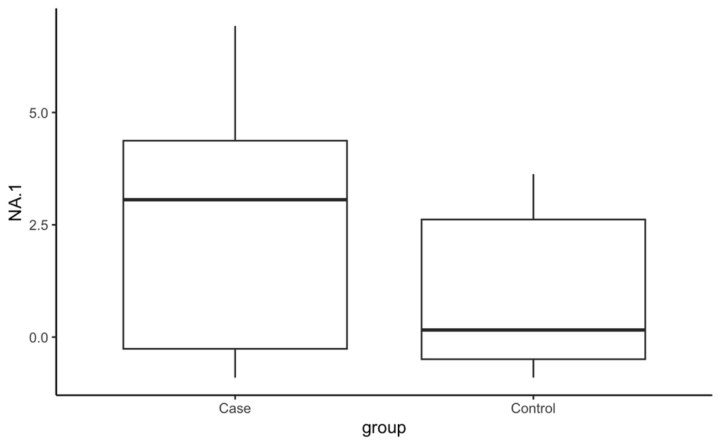

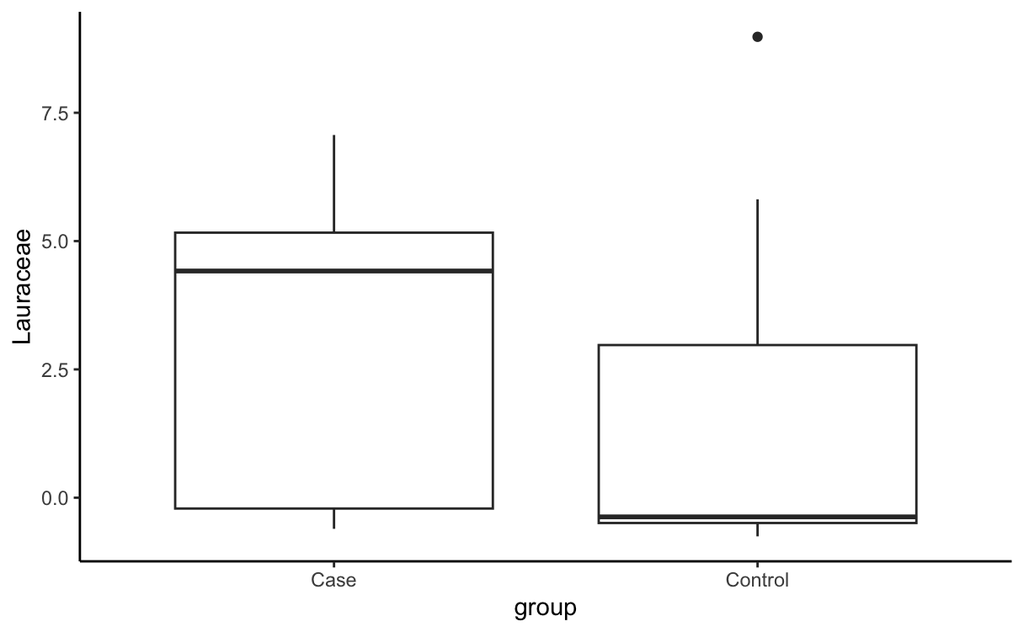

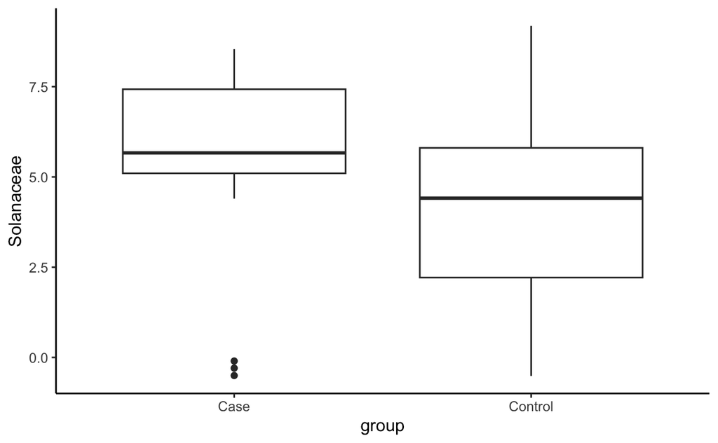

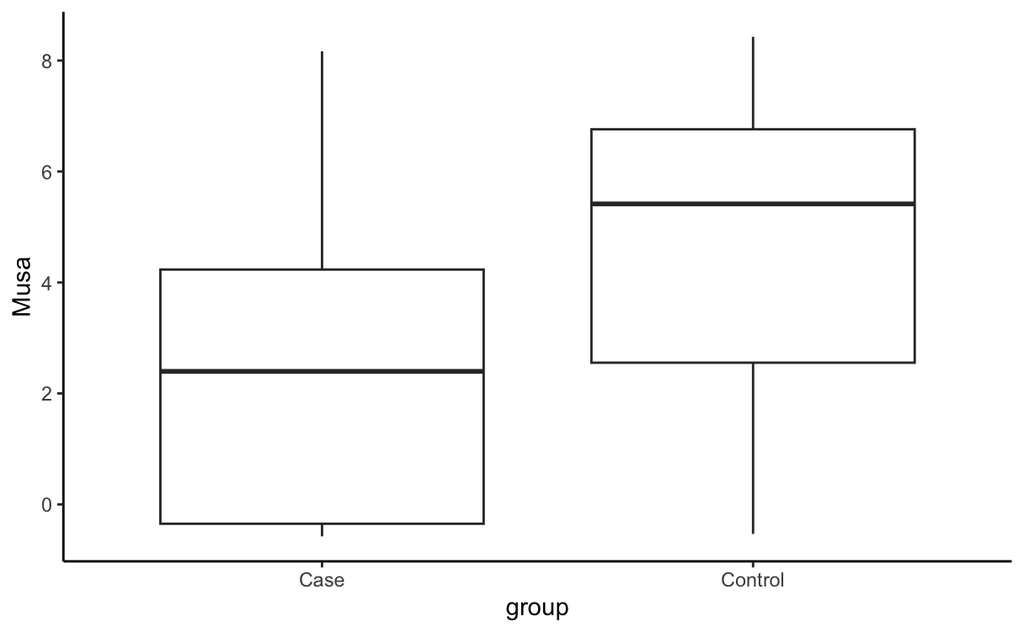

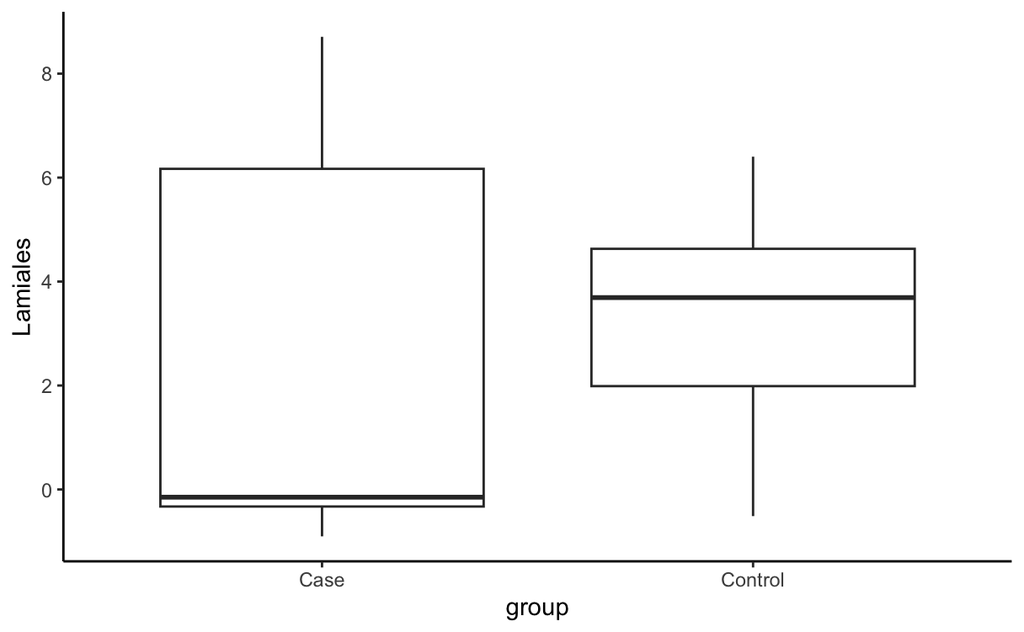

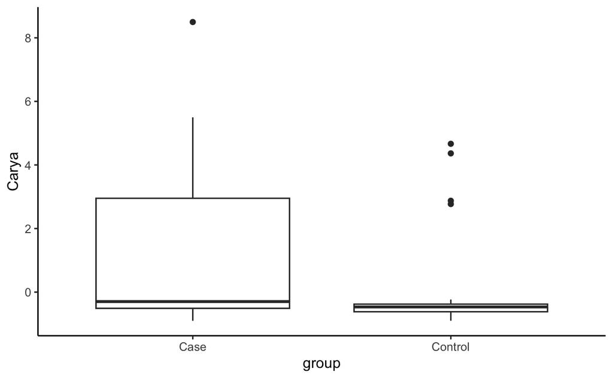

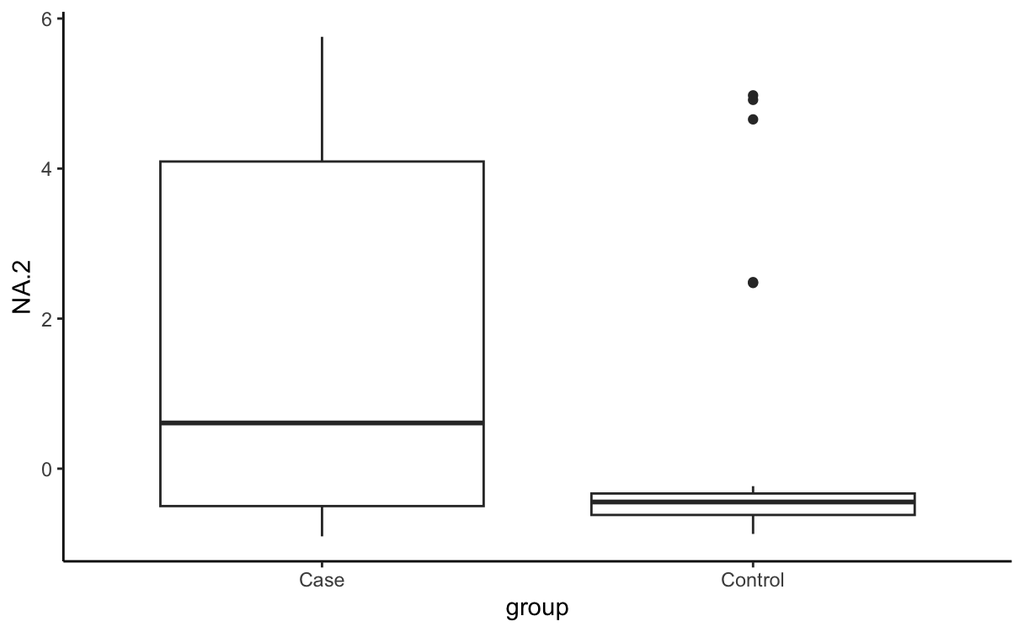

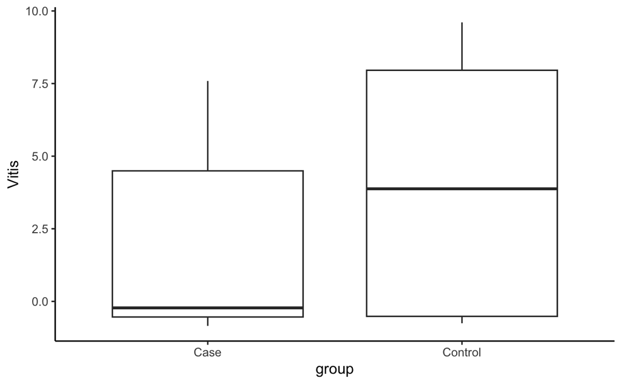

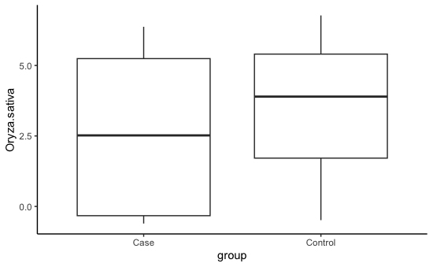

```r
lookup_asv %>%
  filter(name == "Carya") %>%
  pull(asv)
```

```
[1] "ATCCTGTTTTCTAAAAACAAATTAAGGGTTCATAAAGCGAGAATCAAAAAG"
```